# Comportamento Audiência - Estudio C

Jean Carlos Maia

2017-08-02

O objetivo é explorar a relação Tag - Resultado Ibope

Vamos analisar o comportamento da `Audiência Individual` ao longo de 2016 e 2017

## Gráficos

Abaixo segue a relação com todos os gráficos comportamentais.

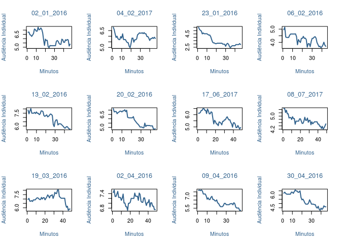

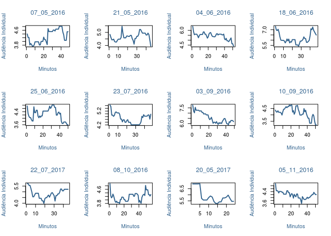

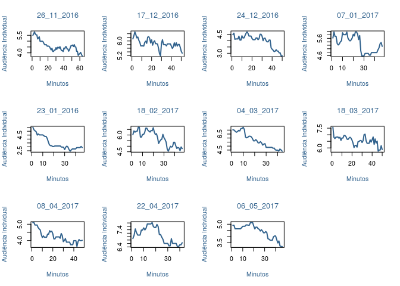

Criação da métrica para quantificar o `comportamento diário`

## Quantificando os gráficos

Para esta análise foi implementada a métrica de `Fator de crescimento`. Ela é derivada de um padrão estatístico que possui esta descrição:

Fator de crescimento relaciona as subidas e descidas, tempo e nível da inclinação. Com isto chega-se à métrica `Fator de crescimento`.

As características desses número:

1. O valor negativo implica em um comportamento descrito majoritariamente por quedas.
2. O valor positivo implica em um comportamento descrito majoritariamente por subidas.
3. Quanto maior o número, mais íngreme é este comportamento.
- Esta métrica ignora ruídos.

Na tabela abaixo temos a relação `Dia` e `Fator de Crescimento`:

| FatordeCrescimento | Data |
| --- | --- |
| -12.8508994 | 02/01/2016 |
| -23.2369501 | 09/01/2016 |
| -14.0303226 | 23/01/2016 |
| -25.8160581 | 06/02/2016 |
| -16.7538809 | 13/02/2016 |
| -15.5959433 | 20/02/2016 |
| -14.5617577 | 27/02/2016 |
| -21.2991517 | 12/03/2016 |
| -5.0138834 | 19/03/2016 |
| -36.5313887 | 02/04/2016 |
| -17.2559040 | 09/04/2016 |
| -15.3606915 | 30/04/2016 |
| 26.3343507 | 07/05/2016 |
| 13.9257226 | 21/05/2016 |
| -29.1968673 | 04/06/2016 |
| 1.4946536 | 18/06/2016 |
| -10.8272948 | 25/06/2016 |
| -13.4154733 | 23/07/2016 |
| -24.0898993 | 03/09/2016 |
| -22.1127684 | 10/09/2016 |
| -42.9832965 | 24/09/2016 |
| 23.4472388 | 08/10/2016 |
| -15.3216848 | 22/10/2016 |
| -39.4273192 | 05/11/2016 |
| -30.3096264 | 26/11/2016 |
| -34.9853393 | 17/12/2016 |
| -22.0368511 | 24/12/2016 |
| -18.7612874 | 07/01/2017 |
| -9.3282316 | 21/01/2017 |
| 0.7147242 | 04/02/2017 |
| -17.3813922 | 18/02/2017 |
| -13.1709869 | 04/03/2017 |
| -26.3060735 | 18/03/2017 |
| -31.8118031 | 08/04/2017 |
| -18.1233000 | 22/04/2017 |
| -20.5868234 | 06/05/2017 |
| -8.4566850 | 20/05/2017 |
| -23.4864276 | 17/06/2017 |
| -41.9787120 | 08/07/2017 |
| 0.4848867 | 22/07/2017 |

# Aproximadamente 85% dos dias apresentaram comportamento de queda.

Vamos usar outra métrica para conferir se de fato, comportamento de queda caracteriza o resultado de audiência.

## Valor de probabilidade.

Aqui aplicamos uma nova métrica: pValue. Ela traduz a similaridade entre a compilação de todos resultados e uma data específica. Quanto maior o pValue, mais similar.

Em outras palavras, o pValue nos mostra o dia que `Melhor descreve o resultado geral do Estúdio C`. Podemos assim, derivar os dias que melhor representam o resultado total do Programa.

Uma observação: O pValue mede a relação de padrão. Fazendo-a independente da métrica anterior: Fator de Crescimento.

| Data | FatordeCrescimento | PValue |
| --- | --- | --- |
| 07/01/2017 | -18.761287 | 0.2241375 |
| 30/04/2016 | -15.360691 | 0.0444005 |
| 27/02/2016 | -14.561758 | 0.0229457 |
| 22/10/2016 | -15.321685 | 0.0224763 |
| 04/03/2017 | -13.170987 | 0.0016509 |
| 04/06/2016 | -29.196867 | 0.0001176 |
| 20/05/2017 | -8.456685 | 0.0000045 |
| 18/02/2017 | -17.381392 | 0.0000037 |

Vemos que os dias que melhor descrevem o comportamento do Estúdio C possuem Fator de Crescimento `negativo`.

Então, o comportamento de queda caracteriza a audiência.

# Conclusões

1. Faz sentido continuar a atribuir o resultado do dia à tag. O comportamento é `padronizado`.
2. Projetar estratégias diferentes de divulgação do conteúdo. `personalização`.
3. Propostas diferenciadas de `interatividade`.

# Anexo: Comportamento de outros targets

## Avaliando os targets:

`AS1217`, `AS2534`, `AS4049` e `Audiência Domiciliar`

### AS1217

| Data | FatordeCrescimento | PValue |
| --- | --- | --- |
| 06/02/2016 | -10.0000000 | 0.3306692 |
| 22/10/2016 | -10.6818182 | 0.0948239 |
| 20/05/2017 | 1.1695906 | 0.0064690 |
| 17/12/2016 | -8.5791054 | 0.0033298 |
| 07/05/2016 | 21.0526316 | 0.0022212 |
| 04/02/2017 | -11.4177548 | 0.0014142 |
| 23/07/2016 | 26.0692328 | 0.0002423 |
| 18/02/2017 | -5.6408167 | 0.0001111 |
| 03/09/2016 | -4.8429806 | 0.0000805 |
| 12/03/2016 | 0.9129959 | 0.0000340 |

### AS2534

| Data | FatordeCrescimento | PValue |
| --- | --- | --- |
| 23/01/2016 | -6.445763 | 0.6959395 |
| 24/12/2016 | -12.000597 | 0.5304472 |
| 05/11/2016 | -8.713314 | 0.3767396 |
| 30/04/2016 | -13.933593 | 0.1430466 |
| 22/04/2017 | -14.815474 | 0.0718313 |
| 17/12/2016 | -17.559716 | 0.0334312 |
| 07/01/2017 | 12.454335 | 0.0200632 |
| 18/03/2017 | -7.572541 | 0.0142572 |
| 08/04/2017 | -7.923397 | 0.0003644 |
| 21/05/2016 | 8.810027 | 0.0002799 |

### AS3539

| Data | FatordeCrescimento | PValue |
| --- | --- | --- |
| 09/04/2016 | -12.798587 | 0.8610427 |
| 22/10/2016 | -19.149284 | 0.5834095 |
| 09/01/2016 | -8.197869 | 0.2082730 |
| 08/04/2017 | 10.821974 | 0.0840212 |
| 30/04/2016 | -7.490966 | 0.0678855 |
| 13/02/2016 | 2.440837 | 0.0290822 |
| 23/07/2016 | -4.812456 | 0.0192543 |
| 17/12/2016 | 6.368938 | 0.0183913 |
| 04/02/2017 | -7.691617 | 0.0013236 |
| 20/05/2017 | -2.471558 | 0.0005240 |

### AS4049

| Data | FatordeCrescimento | PValue |
| --- | --- | --- |
| 06/05/2017 | -8.819111 | 0.3393103 |
| 19/03/2016 | -1.293387 | 0.3233459 |
| 18/06/2016 | -2.947934 | 0.2689105 |
| 04/02/2017 | -15.566103 | 0.2495368 |
| 03/09/2016 | 15.349666 | 0.0291902 |
| 22/10/2016 | -13.076456 | 0.0231750 |
| 27/02/2016 | -7.738097 | 0.0213775 |
| 17/06/2017 | -3.171305 | 0.0077852 |
| 10/09/2016 | 4.418614 | 0.0008758 |
| 02/04/2016 | -5.207689 | 0.0001536 |

### Audiência Domiciliar

| Data | FatordeCrescimento | PValue |
| --- | --- | --- |
| 04/02/2017 | -8.0654033 | 0.9848844 |
| 07/01/2017 | -8.6189569 | 0.9240064 |
| 22/10/2016 | -6.3134953 | 0.6605334 |
| 30/04/2016 | -7.1925253 | 0.5627205 |
| 08/07/2017 | -16.8490621 | 0.5293884 |
| 27/02/2016 | -8.1731373 | 0.0931067 |
| 22/07/2017 | -0.9076859 | 0.0566608 |
| 06/05/2017 | -8.9173562 | 0.0062055 |
| 02/01/2016 | -5.8729673 | 0.0000152 |
| 20/02/2016 | -7.9772067 | 0.0000045 |